# Reproducible Research: Peer Assessment 1

## Loading and preprocessing the data

```r
library(dplyr)
```

```r
library(ggplot2)
unzip("activity.zip")
activity<-read.csv("activity.csv")
activity$date<-as.Date(activity$date)
```

## What is mean total number of steps taken per day?

Histogram of the total number of steps taken each day

```r
g<-activity %>% dplyr::group_by(date)
Sum_step<-summarise(g,sum=sum(steps))
```

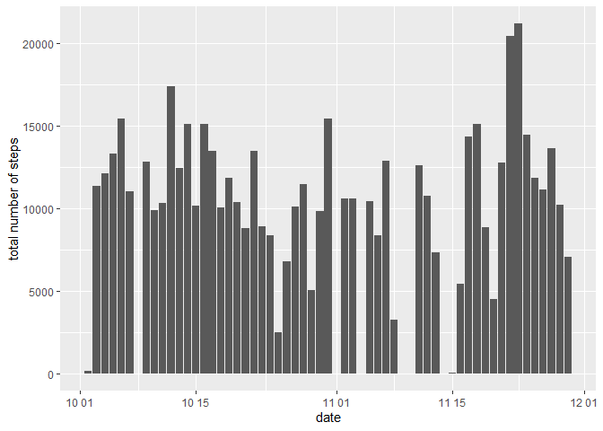

```r
ggplot(Sum_step,aes(date,sum))+geom_bar(stat="identity")+labs(y="total number of steps")
```

```r
dev.copy(png,file= "Plot1.png")
```

```r
dev.off()
```

Mean and median number of steps taken each day

```r
summary(Sum_step$sum)
```

```
##    Min. 1st Qu.  Median    Mean 3rd Qu.    Max.    NA's
##      41    8841   10765   10766   13294   21194       8
```

## What is the average daily activity pattern?

Time series plot of the average number of steps taken

```r
activity$interval<-factor(activity$interval)
act_com<-activity[!is.na(activity$steps),]
gr<-act_com %>% dplyr::group_by(interval)
ave_step<-summarise(gr,mean=mean(steps))
```

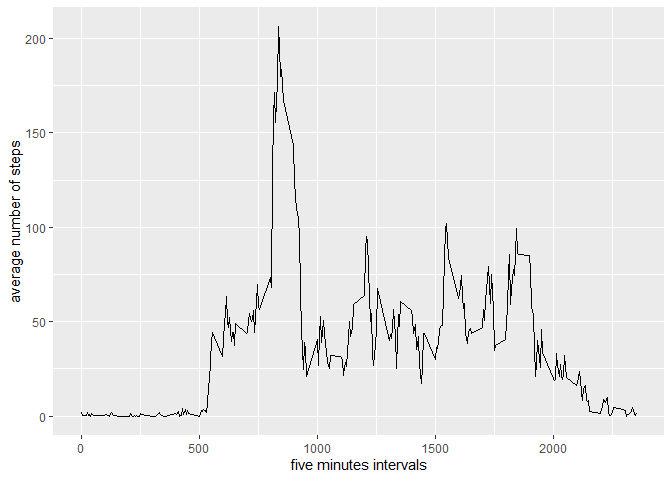

```r
ave_step$interval<-as.numeric(as.character(ave_step$interval))
ggplot(ave_step,aes(interval,mean))+geom_line()+labs(x="five minutes intervals", y="average number of steps")
```

```r
dev.copy(png,file= "Plot2.png")
```

```r
dev.off()
```

The 5-minute interval, on average across all the days in the dataset, which contains the maximum number of steps is

```r
ave_step[which(ave_step$mean==max(ave_step$mean)),1]
```

```
## # A tibble: 1 x 1
##   interval
##      <dbl>
## 1      835
```

## Imputing missing values

Calculate and report the total number of missing values in the dataset

```r
nrow(activity[is.na(activity$steps),])
```

```
## [1] 2304
```

Devise a strategy for filling in all of the missing values in the dataset. The strategy does not need to be sophisticated(mean of steps here)

```r
m<-mean(activity$steps,na.rm = T)
newdf<-activity
newdf[is.na(activity$steps),1]<-m
```

Create a new dataset that is equal to the original dataset but with the missing data filled in.

```r
newdf
```

```
##          steps       date interval
## 1      37.3826 2012-10-01        0
## 2      37.3826 2012-10-01        5
## 3      37.3826 2012-10-01       10
## 4      37.3826 2012-10-01       15
## 5      37.3826 2012-10-01       20
## 6      37.3826 2012-10-01       25
## 7      37.3826 2012-10-01       30
## 8      37.3826 2012-10-01       35
## 9      37.3826 2012-10-01       40
## 10     37.3826 2012-10-01       45
## 11     37.3826 2012-10-01       50
## 12     37.3826 2012-10-01       55
## 13     37.3826 2012-10-01      100
## 14     37.3826 2012-10-01      105
```

[output cut: 17554 more lines]

```r
str(newdf)
```

```
## 'data.frame':    17568 obs. of  3 variables:
##  $ steps   : num  37.4 37.4 37.4 37.4 37.4 ...
##  $ date    : Date, format: "2012-10-01" "2012-10-01" ...
##  $ interval: Factor w/ 288 levels "0","5","10","15",..: 1 2 3 4 5 6 7 8 9 10 ...
```

Make a histogram of the total number of steps taken each day and Calculate

```r
dg<-newdf %>% dplyr::group_by(date)
Sum_df<-summarise(dg,sum=sum(steps))
```

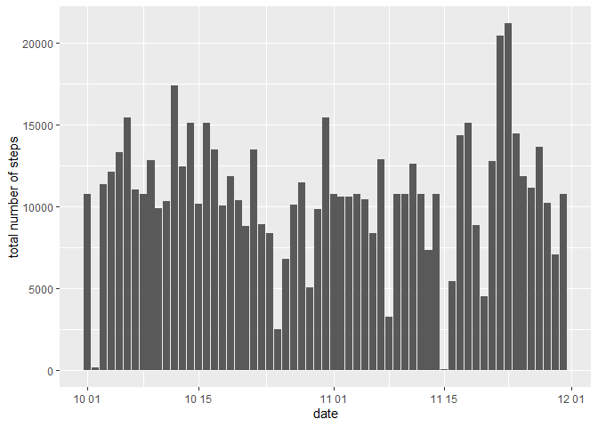

```r
ggplot(Sum_df,aes(date,sum))+geom_bar(stat="identity")+labs(y="total number of steps")
```

```r
dev.copy(png,file= "Plot3.png")
```

```r
dev.off()
```

report the mean and median total number of steps taken per day.

```r
summary(Sum_df$sum)
```

```
##    Min. 1st Qu.  Median    Mean 3rd Qu.    Max.
##      41    9819   10766   10766   12811   21194
```

Do these values differ from the estimates from the first part of the assignment? What is the impact of imputing missing data on the estimates of the total daily number of steps?

```r
med<-merge(Sum_step$sum,Sum_df$sum)
colnames(med)<-c("is_NA","no_NA")
summary(med)
```

```
##      is_NA           no_NA
##  Min.   :   41   Min.   :   41
##  1st Qu.: 8841   1st Qu.: 9819
##  Median :10765   Median :10766
##  Mean   :10766   Mean   :10766
##  3rd Qu.:13294   3rd Qu.:12811
##  Max.   :21194   Max.   :21194
##  NA's   :488
```

## Are there differences in activity patterns between weekdays and weekends?

Create a new factor variable in the dataset with two levels – “weekday” and “weekend” indicating whether a given date is a weekday or weekend day.

```r
newdf2<-mutate(newdf,status=weekdays(newdf$date))
newdf2$status<-gsub("土曜日","weekend",newdf2$status)
newdf2$status<-gsub("日曜日","weekend",newdf2$status)
newdf2$status<-gsub("[^weekend]曜日","weekday",newdf2$status)
newdf2
```

```
##          steps       date interval  status
## 1      37.3826 2012-10-01        0 weekday
## 2      37.3826 2012-10-01        5 weekday
## 3      37.3826 2012-10-01       10 weekday
## 4      37.3826 2012-10-01       15 weekday
## 5      37.3826 2012-10-01       20 weekday
## 6      37.3826 2012-10-01       25 weekday
## 7      37.3826 2012-10-01       30 weekday
## 8      37.3826 2012-10-01       35 weekday
## 9      37.3826 2012-10-01       40 weekday
## 10     37.3826 2012-10-01       45 weekday
## 11     37.3826 2012-10-01       50 weekday
## 12     37.3826 2012-10-01       55 weekday
## 13     37.3826 2012-10-01      100 weekday
## 14     37.3826 2012-10-01      105 weekday
```

[output cut: 17554 more lines]

Make a panel plot containing a time series plot of the 5-minute interval (x-axis) and the average number of steps taken, averaged across all weekday days or weekend days (y-axis). See the README file in the GitHub repository to see an example of what this plot should look like using simulated data.

```r
newdf2$interval<-factor(newdf2$interval)
gdf<-newdf2 %>% dplyr::group_by(interval,status)
ave_df<-summarise(gdf,mean=mean(steps))
```

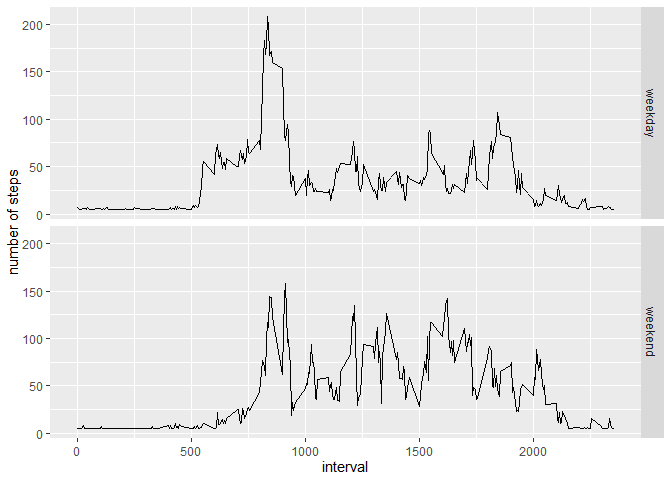

```r
ave_df$interval<-as.numeric(as.character(ave_df$interval))
ggplot(ave_df,aes(interval,mean))+geom_line()+facet_grid(status~.)+labs(y="number of steps")
```

```r
dev.copy(png,file= "Plot4.png")
```

```r
dev.off()
```